# coursework_part1_v1

## Machine Learning Coursework (Part 1)

For the coursework, please make sure to implement your own code and not use libraries (except where explicitly asked). You will need to present your own code that performs nested cross-validation and the k-nearest neighbour algorithm, build confusion matrices, and estimate distances between data samples.

The purpose of this coursework is to help you:

- Get familiar with **common python modules / functions** used for ML in python
- Get practical experience **implementing** ML methods in python
- Get practical experience regarding **parameter selection** for ML methods
- Get practical experience on **evaluating** ML methods and applying cross-validation

Notes:

- don't use libraries that implement kNN or cross-validation. We want to see your code!
- Remember to comment all of your code (see here for tips: https://stackabuse.com/commenting-python-code/). You can also make use of Jupyter Markdown, where appropriate, to improve the layout of your code and documentation.
- Please add docstrings to all of your functions (so that users can get information on inputs/outputs and what each function does by typing SHIFT+TAB over the function name. For more detail on python docstrings, see here: https://numpydoc.readthedocs.io/en/latest/format.html)
- When a question allows a free-form answer (e.g. what do you observe?), create a new markdown cell below and answer the question in the notebook.
- Always save your notebook when you are done (this is not automatic)!
- Upload your completed notebook using the VLE

Plagiarism: please make sure that the material you submit has been created by you. Any sources you use for code should be properly referenced. Your code will be checked for plagiarism using appropriate software.

### Marking

The grades in this coursework are allocated approximately as follows:

|  | mark |
| --- | --- |
| Data exploration (+ 2 questions) | 10 |
| Code, docu. & comments (KNN + Evaluation + NCV) | 10 |
| Results (KNN folds + Summary + Confusion matrices) | 10 |
| Final questions: | 10 |
| Overall quality & use of Markdown | 10 |
| Total available | **50** |

## 1. Exploratory Data Analysis

In this coursework we are going to be working with the **Wine** dataset. This is a 178 sample dataset that categorises 3 different types of Italian wine using 13 different features. The code below loads the Wine dataset and selects a subset of features for you to work with.

```python
# Set matplotlib backend to inline
%matplotlib inline

# Import modules
from sklearn import datasets
import numpy as np
import matplotlib.pyplot as plt
import pandas as pd
import seaborn as sns

# Load data
wine = datasets.load_wine()
# print(wine.DESCR)

# This dataset has 13 features, we will only choose a subset of these
df_wine = pd.DataFrame(wine.data, columns = wine.feature_names )
selected_features = ['alcohol','flavanoids','color_intensity','ash']

# Extract the data as numpy arrays of features, X, and target, y
X = df_wine[selected_features].values
y = wine.target
```

### 1.1. Visualising the data

The first part of tackling any ML problem is visualising the data in order to understand some of the properties of the problem at hand. When there are only a small number of classes and features, it is possible to use scatter plots to visualise interactions between different pairings of features.

Your first task is to recreate a similar grid for the **Wine** dataset, with each off-diagonal subplot showing the interaction between two features, and each of the classes represented as a different colour. The on-diagonal subplots (representing a single feature) should show a distribution (or histogram) for that feature.

You should create a function that, given data X and labels y, plots this grid. The function should be invoked something like this:

```
myplotGrid(X,y,...)
```

where X is your training data and y are the labels (you may also supply additional optional arguments). You can use an appropriate library to help you create the visualisation. You might want to code it yourself using matplotlib functions scatter and hist - however, this is not strictly necessary here, so try not spend too much time on this.

```python
# Define plotting function
def myplotGrid(X, y):
    """
    Creates subplots for relationships between three features

    Parameters
    ----------
    X = Feature data array
    y = Target data array
    """
    # Create the grid of subplots
    fig, ax = plt.subplots(4, 4, figsize = (10, 10))

    # Iterate through each subplot
    for i in range(len(selected_features)):
        for j in range(len(selected_features)):
            # If on the diagonal, plot a histogram of the feature
            if i == j:
                for k in range(3):
                    sns.histplot(X[:, i][y == k], ax = ax[i][j], color = np.array(['red', 'green', 'blue'])[k])
            # Otherwise, plot the interaction between the two features
            else:
                ax[i][j].scatter(X[:, i], X[:, j], edgecolors='white', color = np.array(['red', 'green', 'blue'])[y])
           # Add labels to the x-axis
            if i == 3:
                ax[i][j].set_xlabel(selected_features[j])
            else:
                ax[i][j].set_xlabel('')
            # Add labels to the y-axis
            if j == 0:
                ax[i][j].set_ylabel(selected_features[i])
            else:
                ax[i][j].set_ylabel('')

    # Show the plot
    plt.show()
```

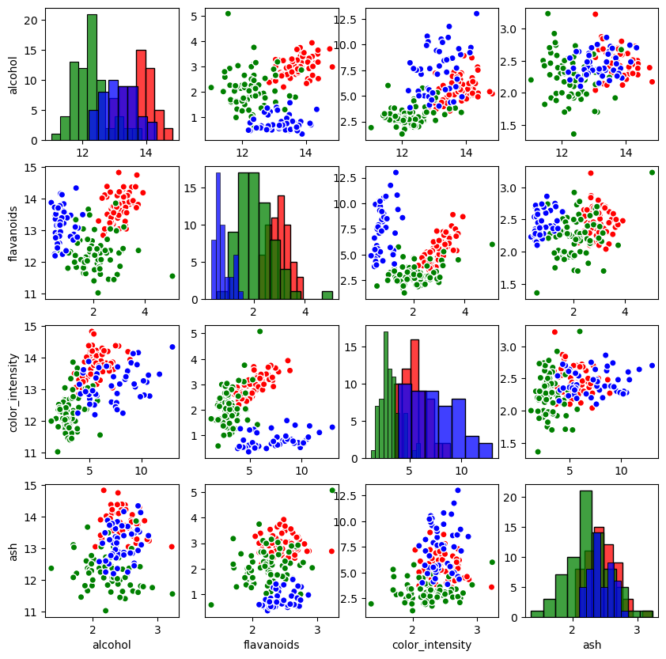

```python
# Run the plotting function
myplotGrid(X, y)
```

### 1.2. Exploratory Data Analysis under noise

When data are collected under real-world settings they usually contain some amount of noise that makes classification more challenging. In the cell below, invoke your exploratory data analysis function above on a noisy version of your data X.

Try to perturb your data with some Gaussian noise,

```
# initialize random seed to replicate results over different runs
mySeed = 12345
np.random.seed(mySeed)
XN=X+np.random.normal(0,0.6,X.shape)
```

and then invoke

```
myplotGrid(XN,y)
```

```python
# Noise code
mySeed = 666
np.random.seed(mySeed)
XN = X + np.random.normal(0, 0.6, X.shape)
```

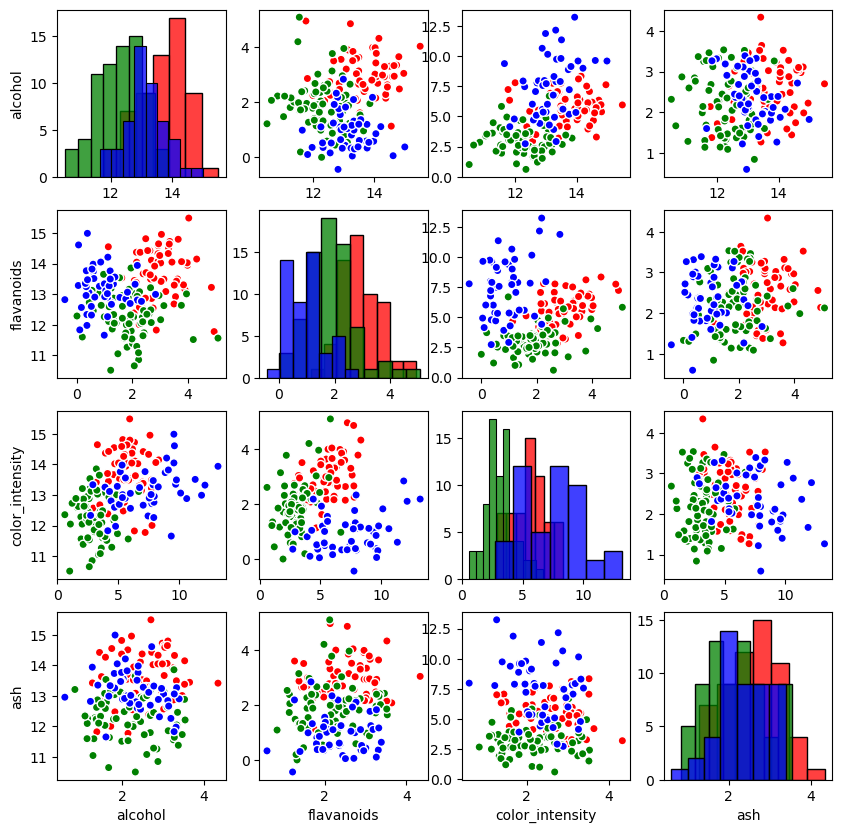

```python
# Run the plotting function with noise seed
myplotGrid(XN,y)
```

### Q1. Exploratory data analysis

Based on your exploratory analysis, if you were to build a classifier using only two of the available features, which ones would you choose and why? Answer as fully as you can.

> I would use 'alcohol' and 'color_intensity' as they seem to have a linear relationship on the both the plots with and without noise. A linear relationship between a pair of features and the target variable is one in which the value of the target variable changes in a predictable, linear fashion as the value of the features changes. For example, if there is a strong, linear relationship between the length of a fish and its weight, this means that as the length of the fish increases, the weight of the fish increases in a predictable, linear fashion. In this case, it can be observed that as the color intensity increases, the alcohol level also increases.

### Q2. Data with noise

What do you observe by plotting the data without noise compared to plotting with added Gaussian noise?

> Plotting the data without noise makes the points on the plot seem more closely grouped together, while plotting with Gaussian noise makes the points on the plot seem more spread out.

## 2. Implementing kNN

In the cell below, develop your own code for performing k-Nearest Neighbour classification. You may use the scikit-learn k-NN implementation from the labs as a guide - and as a way of verifying your results - but it is important that your implementation does not use any libraries other than the basic numpy and matplotlib functions.

Define a function that performs k-NN given a set of data. Your function should be invoked similary to:

```
    y_ = mykNN(X,y,X_,options)
```

where X is your training data, y is your training outputs, X_ are your testing data and y_ are your predicted outputs for X_. The options argument (can be a list or a set of separate arguments depending on how you choose to implement the function) should at least contain the number of neighbours to consider as well as the distance function employed.

Hint: it helps to break the problem into various sub-problems, implemented as helper function. For example, you might want to implement separate function(s) for calculating the distances between two vectors. And another function that uncovers the nearest neighbour(s) to a given vector.

```python
# Remove keepdims warning
import warnings

warnings.simplefilter('ignore')
```

```python
# Helper functions
def train_test_split(X, y, test_set_size):
    """
    Splits data into training and test sets

    Parameters
    ----------
    X = Feature data array
    y = Target data array
    test_set_size = Percentage of data used for testing

    Return
    ------
    X_train = Training set (Input)
    y_train = Training set (Output)
    X_test = Testing set (Input)
    y_test = Testing set (Predict)
    """
    # Create list of integers from 0 to number of rows in X
    data = list(range(X.shape[0]))

    # Shuffle the data randomly
    np.random.shuffle(data)

    # Calculate the size of the test set
    training_set_size = int((1 - test_set_size) * X.shape[0])

    # Split the data into training and test sets
    test_set = data[training_set_size:]
    train_set = data[:training_set_size]

    # Split the training and test sets into X and y data
    X_train = X[train_set]
    y_train = y[train_set]
    X_test = X[test_set]
    y_test = y[test_set]

    return X_train, y_train, X_test, y_test

def euclidean_distance(d1, d2):
    """
    Uses Euclidean function to calculate distance between two points

    Parameters
    ----------
    p1 = Number
    p2 = Number

    Return
    ------
    Distance number
    """
    return np.sqrt(np.sum((d1 - d2) ** 2))
```

```python
# My KNN code
def mykNN_Euclidean(X, y, X_, k):
    """
    Uses Euclidean function to perform KNN

    Parameters
    ----------
    X = Training dataset
    y = Training outputs
    X_ = Test dataset
    k = Number of nearest neighbours

    Return
    ------
    y_ = X_ output prediction
    """
    # Initialize an empty list
    y_ = []

    for i in X_:
        # For every item in the test dataset, we initialize a distance list
        distances = []

        # Calculate Euclidean distances between current test data (j) and all training data (i)
        for j in range(len(X)):
            sample_distances = euclidean_distance(np.array(X[j, :]), i)
            distances.append(sample_distances)

        # Convert the list of distances to a numpy array
        distances = np.array(distances)

        # Sort in descending order, up to 'k' elements
        neighbours = np.argsort(distances)[:k]

        # Initialize dictionary to count occurrences in training output dataset
        neighbours_dict = {}

        # Loop through all neighbours after sorting
        for n in neighbours:
            if y[n] in neighbours_dict:
                neighbours_dict[y[n]] += 1
            else:
                neighbours_dict[y[n]] = 1 # An entry in the dictionary exists so we set it to 1. We only want to initialize what's needed.

        # Once we have all the dictionaries, we want the highest number of occurrences
        y_.append(max(neighbours_dict, key = neighbours_dict.get))

    # Return the predicted labels
    return np.array(y_)
```

```python
# Verfication of results
X_train, y_train, X_test, y_test = train_test_split(X, y, 0.2)
y_ = mykNN_Euclidean(X_train, y_train, X_test, 9)

# Actual values
print('y_test', y_test)

# Predicted values
print('y_    ', y_)
```

```
y_test [2 2 1 0 1 0 1 1 2 1 2 0 2 2 2 0 2 1 1 0 1 1 2 0 0 0 0 0 1 1 2 1 1 0 1 1]
y_     [2 2 1 0 1 0 0 0 2 1 2 0 2 2 2 0 2 1 1 0 1 0 2 0 0 0 0 0 1 0 2 1 1 0 1 1]
```

## 3. Classifier evaluation

In the cell below, implement your own classifier evaluation code. This should include some way of calculating confusion matrices, as well as common metrics like accuracy.

Write some additional code that lets you display the output of your confusion matrices in a useful and easy-to-read manner.

You might want to test your functions on some test data, and compare the results to the sklearn library versions.

```python
# My evaluation functions
def my_confusion_matrix(y_ground, y_, classno):
    # Initialize confusion matrix with all zeros
    C = np.zeros((classno, classno), dtype=int)

    # Loop through ground truth and predicted labels
    for gt, pred in zip(y_ground, y_):
        # Increment count in the confusion matrix for corresponding ground truth and predicted label
        C[gt, pred] += 1

    return C

def my_accuracy(y_ground, y_):
    # Initialize count of correct predictions
    correct = 0

    # Loop through ground truth and predicted labels
    for gt, pred in zip(y_ground, y_):
        # Increment count if predicted label matches ground truth label
        if gt == pred:
            correct += 1

    # Calculate accuracy as number of correct predictions divided by total number of predictions
    return correct / len(y_ground)

def my_precision(y_ground, y_):
    # Get unique classes in ground truth labels
    classes = np.unique(y_ground)

    # Initialize array to store precision for each class
    precision = np.zeros(len(classes))

    # Get confusion matrix
    C = my_confusion_matrix(y_ground, y_, len(classes))

    # Loop through each class
    for i, cls in enumerate(classes):
        # Calculate precision for current class as number of true positives (C[i, i])
        # divided by sum of true positives and false positives (sum of elements in ith column of C)
        precision[i] = C[i, i] / sum(C[:, i])

    return precision

def my_recall(y_ground, y_):
    # Get unique classes in ground truth labels
    classes = np.unique(y_ground)

    # Initialize array to store recall for each class
    recall = np.zeros(len(classes))

    # Get the confusion matrix
    C = my_confusion_matrix(y_ground, y_, len(classes))

    # Loop through each class
    for i, cls in enumerate(classes):
        # Calculate recall for current class as number of true positives (C[i, i])
        # divided by sum of true positives and false negatives (sum of elements in the ith row of C)
        recall[i] = C[i, i] / sum(C[i, :])

    return recall
```

```python
# Verification of results
from sklearn.metrics import confusion_matrix, accuracy_score, precision_score, recall_score

# Confusion matrix
libraryconfusionmatrix = confusion_matrix(y_test, y_)

# Accuracy
libraryaccuracy = accuracy_score(y_test, y_)

# Precision
libraryprecision = precision_score(y_test, y_, average = None)

# Recall
libraryrecall = recall_score(y_test, y_, average = None)
```

```python
# Running my functions

# Confusion matrix
myconfusionmatrix = my_confusion_matrix(y_test, y_, len(np.unique(y)))

# Accuracy
myaccuracy = my_accuracy(y_test, y_)

# Precision
myprecision = my_precision(y_test, y_)

# Recall
myrecall = my_recall(y_test, y_)
```

```
Library confusion matrix:
 [[11  0  0]
 [ 4 11  0]
 [ 0  0 10]]
My confusion matrix:
 [[11  0  0]
 [ 4 11  0]
 [ 0  0 10]]
```

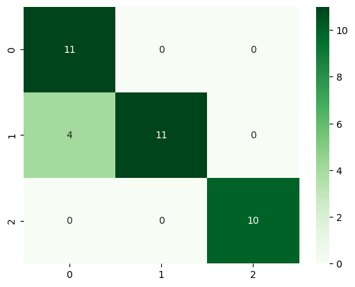

```python
# Verify evaluation functions
import seaborn as sns

# Confusion matrix
print('Library confusion matrix: \n', libraryconfusionmatrix)
print('My confusion matrix: \n', myconfusionmatrix)
sns.heatmap(myconfusionmatrix, annot = True, fmt ='d', cmap ='Greens')
```

```python
# Accuracy
print('Library accuracy: \n', libraryaccuracy)
print('My accuracy: \n', myaccuracy)
```

```
Library accuracy:
 0.8888888888888888
My accuracy:
 0.8888888888888888
```

```python
# Precision
print('Library precision: \n', libraryprecision)
print('My precision: \n', myprecision)
```

```
Library precision:
 [0.73333333 1.         1.        ]
My precision:
 [0.73333333 1.         1.        ]
```

```python
# Recall
print('Library recall: \n', libraryrecall)
print('My recall: \n', myrecall)
```

```
Library recall:
 [1.         0.73333333 1.        ]
My recall:
 [1.         0.73333333 1.        ]
```

## 4. Nested Cross-validation using your implementation of KNN

In the cell below, develop your own code for performing 5-fold nested cross-validation along with your implemenation of k-NN above. You must write your own code -- the scikit-learn module may only be used for verification purposes.

Your code for nested cross-validation should invoke your kNN function (see above). You cross validation function should be invoked similary to:

```
accuracies_fold = myNestedCrossVal(X,y,5,list(range(1,11)),['euclidean','manhattan'],mySeed)
```

where X is your data matrix (containing all samples and features for each sample), 5 is the number of folds, y are your known output labels, `list(range(1,11)` evaluates the neighbour parameter from 1 to 10, and `['euclidean','manhattan',...]` evaluates the distances on the validation sets. mySeed is simply a random seed to enable us to replicate your results.

**Notes:**

- you should perform nested cross-validation on **both** your original data X, as well as the data pertrubed by noise as shown in the cells above (XN)
- you should evaluate **at least** two distance functions
- you should evaluate number of neighbours from 1 to 10
- your function should return a list of accuracies per fold
- for each **fold**, your function should print:
  - the accuracy per distinct set of parameters on the validation set
  - the best set of parameters for the fold after validation
  - the confusion matrix per fold (on the testing set)

```python
# Helper functions
def manhattan_distance(d1, d2):
    """
   Uses Manhattan function to calculate distance between two points

    Parameters
    ----------
    d1 = Number
    d2 = Number

    Return
    ------
    Distance number
    """
    return np.abs(np.array(d1) - np.array(d2)).sum()

def split_fold(X, y, k):
    """
    Splits dataset into 'k' folds

    Parameters
    ----------
    X = Feature data array
    y = Target data array
    k = Number of folds

    Return
    ------
    X_fold
    y_fold
    """
    # Calculate size of each fold
    fold_size = int(X.shape[0] / k)

    # List of integers from 0 to fold_size * k
    indices = list(range(fold_size * k))

    # Shuffle list of indices in place
    np.random.shuffle(indices)

    # Use shuffled indices to rearrange rows of X and y in same order
    X_fold = X[indices]
    y_fold = y[indices]

    return X_fold, y_fold

# Another KNN function that uses Manhattan distance function
def mykNN_Manhattan(X, y, X_, k):
    """
    Uses Manhattan function to calculate distance between two points

    Parameters
    ----------
    X = Training dataset
    y = Training outputs
    X_ = Test dataset
    k = Number of nearest neighbours

    Return
    ------
    y_ = X_ output prediction
    """
    # Initialize an empty list
    y_ = []

    for i in X_:
        # For every item in the test dataset, we initialize a distance list
        distances = []

        # Calculate Manhattan distances between current test data (j) and all training data (i)
        for j in range(len(X)):
            sample_distances = manhattan_distance(np.array(X[j, :]), i)
            distances.append(sample_distances)

        # Convert the list of distances to a numpy array
        distances = np.array(distances)

        # Sort in descending order, up to 'k' elements
        neighbours = np.argsort(distances)[:k]

        # Initialize dictionary to count occurrences in training output dataset
        neighbours_dict = {}

        # Loop through all neighbours after sorting
        for n in neighbours:
            if y[n] in neighbours_dict:
                neighbours_dict[y[n]] += 1
            else:
                neighbours_dict[y[n]] = 1 # An entry in the dictionary exists so we set it to 1. We only want to initialize what's needed.

        # Once we have all the dictionaries, we want the highest number of occurrences
        y_.append(max(neighbours_dict, key = neighbours_dict.get))

    # Return the predicted labels
    return np.array(y_)
```

```python
# My Nested CV code
def nested_CV(X, y, f, r):
    """
    Uses KNN to perform nested cross validation

    Parameters
    ----------
    X = Training dataset
    y = Training outputs
    f = Number of folds
    r = Range of values

    Return
    ------
    results, matrices
    """
    # Initialize empty lists to store scores and results
    euclidean_scores, manhattan_scores, results, matrices = [], [], [], []

    # Split data into 'f' folds
    X_fold, y_fold = split_fold(X, y, f)

    # Calculate the size of each fold
    size = int(len(X) / f)

    # Loop through each fold as test set
    for outer in range(f):

        # Take all folds except current outer fold as training set
        X_copy = X_fold[0: (size * outer)]

        # Concatenate folds to form training set
        X_copy = np.concatenate((X_copy, X_fold[((size * outer) + size):(size * f)]))

         # Take all folds except current outer fold as training set
        y_copy = y_fold[0: (size * outer)]

        # Form the training set
        y_copy = np.concatenate((y_copy, y_fold[((size * outer) + size):(size * f)]))

        # Store Euclidean and Manhattan scores
        accuracy_euclidean_temp = []
        accuracy_manhattan_temp = []

        # Store best values
        best_dist_func = ""
        best_accuracy, best_neighbour = 0, 0
        best_y_output,  best_y_ = [], []

        # Inner fold
        for inner in range(f-  1):
            X_input = X_copy[(inner * size): ((inner * size) + size)]
            X_train = X_copy[0: (inner * size)]
            X_train = np.concatenate((X_train, X_copy[((inner * size) + size):((f - 1) * size)]))

            y_test = y_copy[(inner * size): ((inner * size) + size)]
            y_train = y_copy[0: (inner * size)]
            y_train = np.concatenate((y_train, y_copy[((inner * size) + size):((f - 1) * size)]))

            # Predict the labels for the test set using kNN
            for i in r:
                y_euclidean = mykNN_Euclidean(X_train, y_train, X_test, i)
                y_manhattan = mykNN_Manhattan(X_train, y_train, X_test, i)

                # Calculate accuracy of the predictions using Euclidean distance
                accuracy_euclidean = round(my_accuracy(y_test, y_euclidean), 2)

                # Append accuracy score to list of Euclidean scores
                accuracy_euclidean_temp.append(accuracy_euclidean)
                accuracy_manhattan = round(my_accuracy(y_test, y_manhattan), 2)
                accuracy_manhattan_temp.append(accuracy_manhattan)

                # If Euclidean distance acuracy > current maximum accuracy
                if (accuracy_euclidean > best_accuracy):
                    best_accuracy = accuracy_euclidean
                    best_dist_func = "Euclidean"
                    best_neighbour = i
                    best_y_test = y_test
                    best_y_ = y_euclidean

                if (accuracy_manhattan > best_accuracy):
                    best_accuracy = accuracy_manhattan
                    best_dist_func = "Manhattan"
                    best_neighbour = i
                    best_y_test = y_test
                    best_y_ = y_manhattan

        # Append list of Euclidean scores for current outer fold
        euclidean_scores.append(list(accuracy_euclidean_temp))
        manhattan_scores.append(list(accuracy_manhattan_temp))

        # Results
        results.append([(outer + 1), int(best_accuracy * 100), best_neighbour, best_dist_func, best_y_, best_y_test])
        matrices.append([my_confusion_matrix(best_y_test, best_y_, len(np.unique(y)))])

    return results, matrices
```

```python
# Evaluate clean data code
results, matrices = nested_CV(X, y, 5, list(range(1, 10)))

# Print results
i = 0
for row in results:
    print("Fold: ", row[0])
    print("Accuracy: ", row[1])
    print("Neighbours: ", row[2])
    print("Distance function: ", row[3])
    print("y_: ", row[4])
    print("y_test: ", row[5])
    print(matrices[i], "\n")
    i = i + 1
```

```
Fold:  1
Accuracy:  43
Neighbours:  1
Distance function:  Euclidean
y_:  [2 2 1 0 1 0 1 1 2 1 2 0 2 1 2 0 2 1 1 0 1 1 2 0 0 0 0 1 1 0 2 1 1 0 1 1]
y_test:  [0 0 1 1 0 1 2 1 1 2 2 0 0 2 0 0 0 0 1 0 0 1 0 0 0 2 0 2 1 1 1 1 1 1 1]
[array([[6, 3, 6],
       [4, 8, 2],
       [1, 4, 1]])]

Fold:  2
Accuracy:  40
Neighbours:  1
Distance function:  Euclidean
y_:  [2 2 1 0 1 0 1 1 2 1 2 0 2 1 2 0 2 1 1 0 1 1 2 0 0 0 0 1 1 0 2 1 1 0 1 1]
y_test:  [2 0 0 1 0 2 0 0 2 0 1 0 1 1 1 1 1 2 1 0 1 2 2 0 1 1 0 1 2 1 2 0 2 0 1]
[array([[5, 6, 1],
       [5, 5, 4],
       [1, 4, 4]])]

Fold:  3
Accuracy:  43
Neighbours:  3
Distance function:  Manhattan
y_:  [2 2 1 0 1 0 1 0 2 1 2 0 2 1 2 0 2 1 1 0 1 1 2 0 0 0 0 0 1 1 2 1 1 0 1 1]
y_test:  [2 0 0 1 0 2 0 0 2 0 1 0 1 1 1 1 1 2 1 0 1 2 2 0 1 1 0 1 2 1 2 0 2 0 1]
[array([[6, 5, 1],
       [5, 5, 4],
       [1, 4, 4]])]

Fold:  4
Accuracy:  43
Neighbours:  7
Distance function:  Euclidean
y_:  [2 2 1 0 1 0 0 0 2 1 2 0 2 1 2 0 2 1 1 0 1 0 2 0 0 0 0 0 1 0 2 1 1 0 1 1]
y_test:  [2 0 0 1 0 2 0 0 2 0 1 0 1 1 1 1 1 2 1 0 1 2 2 0 1 1 0 1 2 1 2 0 2 0 1]
[array([[7, 4, 1],
       [6, 4, 4],
       [2, 3, 4]])]

Fold:  5
Accuracy:  46
Neighbours:  1
Distance function:  Euclidean
y_:  [2 2 1 0 1 0 1 1 2 1 2 0 2 2 2 0 2 1 1 0 1 1 2 0 0 0 0 0 1 0 2 1 1 0 1 1]
y_test:  [0 0 1 1 0 1 2 1 1 2 2 0 0 2 0 0 0 0 1 0 0 1 0 0 0 2 0 2 1 1 1 1 1 1 1]
[array([[6, 3, 6],
       [4, 8, 2],
       [2, 2, 2]])]
```

```python
# Evaluate noisy data code
results_noisy, matrices_noisy = nested_CV(XN, y, 5, list(range(1,10)))
```

## 5. Summary of results

Using your results from above, fill out the following table using the **clean** data:

[output not shown]

Now fill out the following table using the **noisy** data:

[output not shown]

```python
# Print the summaries (Clean)
# Please only run this block of code once, or the total value will be added to the previous value
results_df = pd.DataFrame(results, columns = ['Fold', 'Accuracy', 'k', 'Distance', 'y_', 'y_test'])

# Drop the 'y_' and 'y_test' columns
results_df = results_df.drop(columns=['y_', 'y_test'], axis = 1)

if 'Total' in results_df['Fold'].values:
    # Update the values in the 'Total' row
    results_df.loc[results['Fold'] == 'Total', 'Accuracy'] = results_df['Accuracy'].sum()
else:
    # Append a new 'Total' row to the dataframe
    total_row = pd.DataFrame({'Fold': 'Total', 'Accuracy': results_df['Accuracy'].sum(), 'k': np.nan, 'Distance': np.nan}, index=[len(results_df)])
    results_df = results_df.append(total_row, ignore_index=True)

display(results_df)
```

|  | Fold | Accuracy | k | Distance |
| --- | --- | --- | --- | --- |
| 0 | 1 | 43 | 1.0 | Euclidean |
| 1 | 2 | 40 | 1.0 | Euclidean |
| 2 | 3 | 43 | 3.0 | Manhattan |
| 3 | 4 | 43 | 7.0 | Euclidean |
| 4 | 5 | 46 | 1.0 | Euclidean |
| 5 | Total | 215 | NaN | NaN |

```python
# Print the summaries (Noisy)\
# Please only run this block of code once, or the total value will be added to the previous value
results_noisy_df = pd.DataFrame(results_noisy, columns = ['Fold', 'Accuracy', 'k', 'Distance', 'y_', 'y_test'])

# Drop the 'y_' and 'y_test' columns
results_noisy_df = results_noisy_df.drop(columns=['y_', 'y_test'], axis = 1)

if 'Total' in results_noisy_df['Fold'].values:
    # Update the values in the 'Total' row
    results_noisy_df.loc[results_noisy['Fold'] == 'Total', 'Accuracy'] = results_noisy_df['Accuracy'].sum()
else:
    # Append a new 'Total' row to the dataframe
    total_row = pd.DataFrame({'Fold': 'Total', 'Accuracy': results_noisy_df['Accuracy'].sum(), 'k': np.nan, 'Distance': np.nan}, index=[len(results_noisy_df)])
    results_noisy_df = results_noisy_df.append(total_row, ignore_index=True)

display(results_noisy_df)
```

|  | Fold | Accuracy | k | Distance |
| --- | --- | --- | --- | --- |
| 0 | 1 | 40 | 8.0 | Manhattan |
| 1 | 2 | 49 | 7.0 | Euclidean |
| 2 | 3 | 46 | 1.0 | Euclidean |
| 3 | 4 | 49 | 1.0 | Euclidean |
| 4 | 5 | 46 | 3.0 | Euclidean |
| 5 | Total | 230 | NaN | NaN |

### 5.2. Confusion matrix summary

Summarise the overall results of your nested cross validation evaluation of your K-NN algorithm using two summary confusion matrices (one for the noisy data, one for the clean data). You might want to adapt your `myNestedCrossVal` code above to also return a list of confusion matrices.

Use or adapt your evaluation code above to print the two confusion matrices below. Make sure you label the matrix rows and columns. You might also want ot show class-relative precision and recall.

```python
# Clean data summary results
for i in range(len(matrices)):
    print(f"Fold {i + 1}:")
    print(matrices[i], "\n")
```

```
Fold 1:
[array([[6, 3, 6],
       [4, 8, 2],
       [1, 4, 1]])]

Fold 2:
[array([[5, 6, 1],
       [5, 5, 4],
       [1, 4, 4]])]

Fold 3:
[array([[6, 5, 1],
       [5, 5, 4],
       [1, 4, 4]])]

Fold 4:
[array([[7, 4, 1],
       [6, 4, 4],
       [2, 3, 4]])]

Fold 5:
[array([[6, 3, 6],
       [4, 8, 2],
       [2, 2, 2]])]
```

```python
# Noisy data summary results
for i in range(len(matrices_noisy)):
    print(f"Fold {i + 1}:")
    print(matrices_noisy[i], "\n")
```

```
Fold 1:
[array([[3, 3, 2],
       [7, 7, 3],
       [2, 4, 4]])]

Fold 2:
[array([[ 5,  3,  6],
       [ 4, 10,  2],
       [ 2,  1,  2]])]

Fold 3:
[array([[5, 3, 6],
       [4, 9, 3],
       [3, 0, 2]])]

Fold 4:
[array([[ 5,  3,  6],
       [ 4, 10,  2],
       [ 3,  0,  2]])]

Fold 5:
[array([[ 4,  4,  6],
       [ 4, 10,  2],
       [ 1,  2,  2]])]
```

## 6. More questions

Now answer the following questions as fully as you can. The answers should be based on your implementation above. Write your answers in the Markdown cells below each question.

### Q3. Influence of noise

Do the best parameters change when noise is added to the data? Can you say that one parameter choice is better regardless of the data used?

> The presence of noise in the data can impact the performance of a model and potentially change the optimal parameters for the model. Noise can cause the data to become more spread out, which can make it more difficult for the model to accurately capture the underlying patterns in the data. As a result, the model may perform better with different parameters when noise is present compared to when the data is clean.

> However, it is generally not possible to say that one set of parameters is universally better than another, regardless of the data being used. The optimal parameters for a model will depend on the specific characteristics of the data, such as the distribution of the data, the number of features, and the complexity of the problem.

> To determine the best parameters for a specific dataset, it is typically necessary to perform model tuning and evaluation using techniques such as cross-validation. This involves testing the model using a range of different parameters and selecting the ones that result in the best performance on the specific dataset being used.

### Q4. Tie break

Assume that you have selected the number of neighbours to be an even number, e.g., 2. For one of the neighbours, the suggested class is 1, and for the other neighbour the suggested class is 2. How would you break the tie? Write example pseudocode that does this.

> To resolve ties in the model's performance, we can adjust the number of neighbors used. If the current number of neighbors is even, we can increase it by one to ensure that there is no possibility of a tie. Alternatively, selecting an odd number of neighbors will also eliminate the possibility of a tie.

### Q5. Beyond Wine

If you were to run your k-nn algorithm on a new dataset (e.g., the breast cancer dataset, or Iris), what considerations would you need to take into consideration? Outline any changes that might be needed to your code.

> Most of my code was hard-coded to fit very specific requirements. There are 3 main changes I would make to my code: It is important to optimize the code for efficient data processing, especially if the dataset is large or has a large number of features (like the breast cancer dataset). This may involve using optimized data structures and algorithms, as well as parallelization techniques. Additionally, a modular code design can make it easier to reuse and maintain the code, as well as to add new features or modify existing ones. This may involve breaking the code into smaller, self-contained modules and defining clear interfaces between them. Lastly, it is important to handle errors and exceptions gracefully to ensure that the code is robust and can recover from unexpected events. This may involve implementing try-except blocks, as well as logging and debugging features.

References: KNNFromScratch by Krishna Kasaraneni on Github for K-Fold-KNN